# Echocardiogram Presentation

Jacob Noeker

December 18, 2018

# Echocardiography Data

Generated echocardiography data on the mice we were using

- Knockout vs Wild type

Very small data set

- Easy to work with

Needed to be done and was good practice

# Starting with Data

Started by importing the proper package and the data

```
library(readxl)
EchoCardiograms_data_for_R <- read_excel("Echocardiogram_Data/EchoCardiograms data for R.xls",
    sheet = "Sheet3")
View(EchoCardiograms_data_for_R)
EchoC_data <- EchoCardiograms_data_for_R #Renamed for easier use
names(EchoC_data)
```

The data was fairly clean since I made the csv file myself

# Investigated and Manipulation

Using Tidyverse package

```
install.packages("tidyverse")
library(tidyverse)

EchoC_data %>%
  select(ID, Genotype, Vol_s, Vol_d, EF, FS, starts_with('Dia'), starts_with('mean'), starts_with('LV'), Peak_grad, Peak_vel, starts_with('Aor'), brach., -starts_with('RV'), -starts_with('PA'))

anyNA(EchoC_data)
apply(EchoC_data, 2, function(x) sum(is.na(x)))
```

# Generating Plots

Goal is to generate plots to show data in a digestible fashion

```
library(ggplot2)

ggplot(EchoC_data, aes(x = Genotype, y = Vol_s)) + geom_boxplot()

LV_Sys_Vol <- ggplot(EchoC_data, aes(x = Genotype, y = Vol_s)) + geom_violin() + theme_bw() + ylab("Left Ventricular Systolic Volume (uL)") +
  scale_x_discrete(label = c("Wild Type", "Mutant")) + ggtitle("June 2018 Systolic Volume Variation") + theme(plot.title = element_text(hjust = 0.5)) +
  stat_summary(fun.y = mean, geom="point", shape = 18, size  = 3) + stat_summary(fun.y=median,  geom = "point", shape = 3, size = 3, color="blue")

LV_Sys_Vol
```

Liked the layout of violin plot better than the boxplot

- More informative

# Importing Other Data

Have two sets of data I am working with

Use same methods to import and fix data for use

```
library(readxl)
edited_new_echo_r <- read_excel("Echocardiogram_Data/edited_new_echo_r.xls",
                                sheet = "Sept 2018")
apply(edited_new_echo_r, 2, function(x) sum(is.na(x)))
library(tidyverse)
fixed_new_echo <- new_echo_r %>% drop_na()
anyNA(fixed_new_echo)
```

# Statistics

Need stats on data

t-test is all we really need

- Comparing WT and Mutant

```
ttest <- t.test(PWV ~ Genotype, data=fixed_new_echo)
ttest$p.value
```

Decide to go further and run all t-tests at once

```
lapply(new_echo_r[,3:23], function(x) t.test(x ~ new_echo_r$Genotype, var.equal = TRUE))
```

Gave test results for all variables

# Final Plots

Mess with plot and generate final version:

```
LV_Sys_Vol <- ggplot(EchoC_data, aes(x = Genotype, y = Vol_s)) + geom_violin(scale = "area", adjust = .6) + theme_bw() +
  geom_point(size = .5, height = 0, width = 0.05) + #can use geom_jitter to introduce a small amount of random variation to the location of each point to handle overplott
  ylab("Left Ventricular Systolic Volume (uL)") +
  scale_x_discrete(label = c("Wild Type", "Mutant")) +
  ggtitle("June 2018 Systolic Volume Variation") +
  theme(plot.title = element_text(hjust = 0.5)) +
  stat_summary(fun.y = mean, geom="point", shape = 18, size  = 3, color = "red") +
  stat_summary(fun.y=median,  geom = "point", shape = 3, size = 3, color="blue")

LV_Sys_Vol

LV_Sys_Vol_Sept_2 <- ggplot(new_echo_r, aes(x = Genotype, y = LV_Vol_s)) + geom_violin(scale = "area", adjust = .6) + theme_bw() +
  geom_point(size = .5, height = 0, width = 0.05) +
  ylab("Left Ventricular Systolic Volume (uL)") +
  scale_x_discrete(limits = c("Wild_Type", "Mutant"), label = c("Wild Type", "Mutant")) +
  ggtitle("September 2018 Systolic Volume Variation") +
  theme(plot.title = element_text(hjust = 0.5)) +
  stat_summary(fun.y = mean, geom="point", shape = 18, size  = 3, color = "red") +
  stat_summary(fun.y = median,  geom = "point", shape = 3, size = 3, color = "blue")

LV_Sys_Vol_Sept_2
```

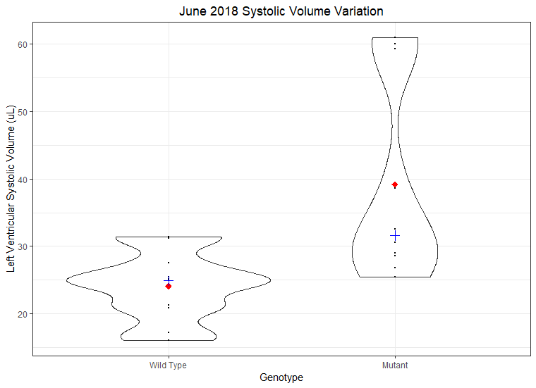

```r
knitr::include_graphics('/Users/Jacob/Documents/my_project/june sys vol.png')
```

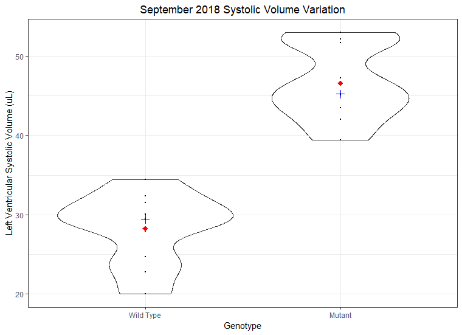

```r
knitr::include_graphics('/Users/Jacob/Documents/my_project/sept sys volume.png')
```

# Next Steps

Used these generated graphs in a lab meeting with a potential collaborator

Now we’re working with them for the next step in our project

# Acknowledgements

Thank you to Dr. Dasgupta!

- Helped with troubleshooting and plot generation

Thank you!

Questions?